# SickKidsSucrose

# Overview

This study was performed in Toronto in Steven Miller’s lab. Preterm infants were scanned shortly after birth, and later at term equivalent age (TEA). Resting state fMRI scans were acquired with ~100 time-points.

Johann processed all scans:

- bias field correction
- registration to preterm and term templates
- brain segmentation (e.g. grey matter masks)
- fMRI motion correction
- fMRI nuisance regression
- Power Spectral Density (PSD) analysis using Welch’s Method to determine Hurst exponent (H)
- registration to 40wk template and group ICA analysis to determine shared resting state networks (RSN)

Data analysis was completed by the end of August 2021. It then came to our attention that the clinical data from SickKids may be incomplete, at which point we stopped performing the statistical analysis.

We received updated clinical data in December 2021. Johann went through and reviewed the changes. As far as we can tell no significant changes were made. We will, however, be using the updated data.

# Hypotheses

Our main hypotheses are:

- H is a sensitive measure of brain development: with greater postmenstrual age (PMA) we will see greater H in fMRI signal, suggesting more efficient, organized, and higher-order processing.
- H will also be sensitive to disruptions in brain development, such as GA: at TEA, infants born younger will have lower H values

# Initial Look at Our Data

Let’s collect and organize our data.

```
##   Subject.ID AGE Birth.age Scan.Age         FD brain_volume gm_volume
## 1 031rq2m4gn v01  28.57143    30.28 0.86920190       232567     50292
## 2 0ls4ecohie v01  29.85714    32.29 0.21814230       224222     54122
## 3 0qcaac4lmj v01  27.28571    33.29 0.57264170       248580     64990
## 4 1haswxytfj v01  29.28571    31.85 0.35913310       224351     50730
## 5 1ixddssthk v01  31.57143    32.57 0.69413860       158886     39227
## 6 1l1gbe9wzu v01  30.42857    33.57 0.08144039       238976     62031
```

## Merge data

```r
networkdata <- read.csv("mean_welch_in_networks_FWHM_5.csv")
newdata <- full_join(loaddata,networkdata, by = c('Subject.ID','AGE'))
loaddata <- newdata
```

## Brain age and Scan age from Initial Cohort

```r
fulldata.age <- loaddata[c(1:4)]
fulldata.age %>% distinct(Subject.ID, .keep_all = TRUE) %>% summarize(Median = median(Birth.age, na.rm=TRUE), Range = range(Birth.age, na.rm=TRUE))
```

```
##     Median    Range
## 1 27.35714 22.71429
## 2 27.35714 31.57143
```

```r
fulldata.age %>% filter(AGE == "v01") %>% summarise(Median = median(Scan.Age), Range = range(Scan.Age), n = n())
```

```
##   Median Range  n
## 1  32.64 27.29 86
## 2  32.64 37.86 86
```

```r
fulldata.age %>% filter(AGE == "v02") %>% summarise(Median = median(Scan.Age), Range = range(Scan.Age), n = n())
```

```
##   Median Range  n
## 1 40.715 34.72 78
## 2 40.715 48.14 78
```

## rename

```r
loaddata <- loaddata %>% rename(gm_m = gm.cort.mean, wm_m = wm.mean, vent_m = vent.mean)
```

```r
fulldata <- loaddata %>% select(!c(gm.cort.mean.no.overlap, csf.std, wm.std, wm.std.no.overlap, csf.mean, cereb.std, gm.deep.std, gm.cort.mean.no.overlap, gm.cort.std.no.overlap, wm.mean.no.overlap, wm.std.no.overlap, visual_std, motor_std, lateral_r_std, cerebellum_std, frontal_std, lateral_l_std, hindbrain_std, posterior_std, cerebellum_std, auditory_std, temporal_lobe_std, gm.cort.std, vent.std, gm.deep.mean, cereb.mean))
```

## More

[note: 16 columns and 158 rows not shown]

There are 164 rows (scans) with 120 unique subjects. This means not all subjects had both their Preterm and TEA scans acquired. Sometimes only the preterm or the TEA scan was acquired.

We have 23 columns of data:

1. Subject ID: unique identification number (factor)
2. Cohort: PMA when scanned; either preterm or TEA (two factors)
3. Gestational Age (weeks): age when the infant was born (continuous)
4. Postmenstrual Age (PMA) at Scan (weeks): age when the infant was scanned (continuous)
5. mean Framewise Displacement (mm): amount of motion when scanned (continuous)
6. Sex (1 = Male, 0 = Female [?]),

# Subjects After MRI Quality Check

Subjects were removed if:

- their anatomical data was deemed too poor to analyze (dHCP fails)
- fMRI volumes < 100
- mean FD > 1 mm

After data quality exclusion, we are left with 132 scans, and 97 unique subjects; meaning we retained 80.83% of subjects.

Of the 97 unique subjects:

- 28 have only preterm scans (of 63 total preterm scans)
- 34 with only TEA scans (of 69 total TEA scans)
- 35 with both preterm and TEA scans.

```r
fullrun.stats_byAGE
```

```
##
##  Descriptive statistics by group
## AGE: v01
##                 vars  n      mean       sd    median   trimmed      mad
## Subject.ID         1 63     47.21    27.37     46.00     46.90    34.10
## AGE                2 63      1.00     0.00      1.00      1.00     0.00
## Birth.age          3 63     27.50     2.51     27.71     27.54     2.75
## Scan.Age           4 63     32.88     1.94     32.72     32.89     1.50
## FD                 5 63      0.45     0.23      0.40      0.44     0.26
## brain_volume       6 63 234212.36 41825.17 232971.00 234344.38 39987.20
## gm_volume          7 63  56769.14 14488.81  54217.00  56275.88 11156.56
## sex                8 63      1.51     0.50      2.00      1.51     0.00
## gm_m               9 63      0.69     0.09      0.69      0.69     0.10
## wm_m              10 63      0.68     0.09      0.68      0.68     0.09
## vent_m            11 63      0.69     0.10      0.69      0.69     0.11
## visual_m          12 63      0.68     0.11      0.68      0.68     0.09
## motor_m           13 63      0.70     0.10      0.71      0.70     0.12
## lateral_r_m       14 63      0.68     0.11      0.68      0.68     0.10
## salient_m         15 63      0.67     0.11      0.67      0.67     0.10
## salient_std       16 63      0.14     0.02      0.14      0.14     0.02
## frontal_m         17 63      0.69     0.10      0.68      0.68     0.08
## lateral_l_m       18 63      0.67     0.09      0.68      0.67     0.09
## hindbrain_m       19 63      0.69     0.09      0.70      0.69     0.08
## posterior_m       20 63      0.67     0.10      0.68      0.67     0.10
## cerebellum_m      21 63      0.68     0.08      0.68      0.68     0.09
## auditory_m        22 63      0.70     0.10      0.69      0.70     0.09
## temporal_lobe_m   23 63      0.68     0.13      0.68      0.69     0.08
##                       min       max     range  skew kurtosis      se
## Subject.ID           1.00     97.00     96.00  0.07    -1.20    3.45
## AGE                  1.00      1.00      0.00   NaN      NaN    0.00
## Birth.age           22.71     31.57      8.86 -0.16    -1.08    0.32
## Scan.Age            27.29     37.86     10.57 -0.04     0.73    0.24
## FD                   0.05      0.97      0.92  0.45    -0.65    0.03
## brain_volume    124442.00 339590.00 215148.00 -0.10     0.38 5269.48
## gm_volume        21738.00  93207.00  71469.00  0.28     0.29 1825.42
## sex                  1.00      2.00      1.00 -0.03    -2.03    0.06
## gm_m                 0.49      0.87      0.38  0.00    -0.57    0.01
## wm_m                 0.47      0.91      0.44  0.09    -0.15    0.01
## vent_m               0.41      0.94      0.53  0.17     0.14    0.01
## visual_m             0.35      0.95      0.61 -0.14     0.71    0.01
```

[output cut: 46 more lines]

```
## gm_m                 0.53      1.13      0.60  0.07     0.43    0.01
## wm_m                 0.52      1.09      0.56  0.05     0.21    0.01
## vent_m               0.53      1.03      0.50  0.06    -0.28    0.01
## visual_m             0.48      1.19      0.71 -0.09    -0.10    0.02
## motor_m              0.51      1.29      0.78  0.36     0.95    0.02
## lateral_r_m          0.54      1.11      0.57  0.34     0.06    0.01
## salient_m            0.50      1.06      0.56 -0.07     0.17    0.01
## salient_std          0.11      0.20      0.09  0.41    -0.53    0.00
## frontal_m            0.49      1.05      0.57 -0.01     0.13    0.01
## lateral_l_m          0.44      1.03      0.59 -0.30     0.00    0.01
## hindbrain_m          0.52      1.04      0.51 -0.30    -0.16    0.01
## posterior_m          0.52      1.01      0.49  0.22    -0.59    0.01
## cerebellum_m         0.52      1.13      0.60  0.25     0.78    0.01
## auditory_m           0.48      1.12      0.64 -0.30     0.51    0.01
## temporal_lobe_m      0.49      1.01      0.51  0.19    -0.13    0.01
```

[figure not shown]

# Demographics

```r
fullruns %>% distinct(Subject.ID, .keep_all = TRUE) %>% filter(sex == 1) %>% summarise(Males = n(), na.rm=TRUE)
```

```
##   Males na.rm
## 1    51  TRUE
```

```r
fullruns %>% filter(AGE == "v01") %>% filter(sex == 1) %>% summarise(Males = n(), na.rm=TRUE)
```

```
##   Males na.rm
## 1    32  TRUE
```

```r
fullruns %>% filter(AGE == "v02") %>% filter(sex == 1) %>% summarise(Males = n(), na.rm=TRUE)
```

```
##   Males na.rm
## 1    36  TRUE
```

# Data Visualization

Let’s visualize some of our variables

## Outcome Variables

### H in GM

Let’s start with our primary outcome variable: H

Let’s look in the greymatter (GM) for now…

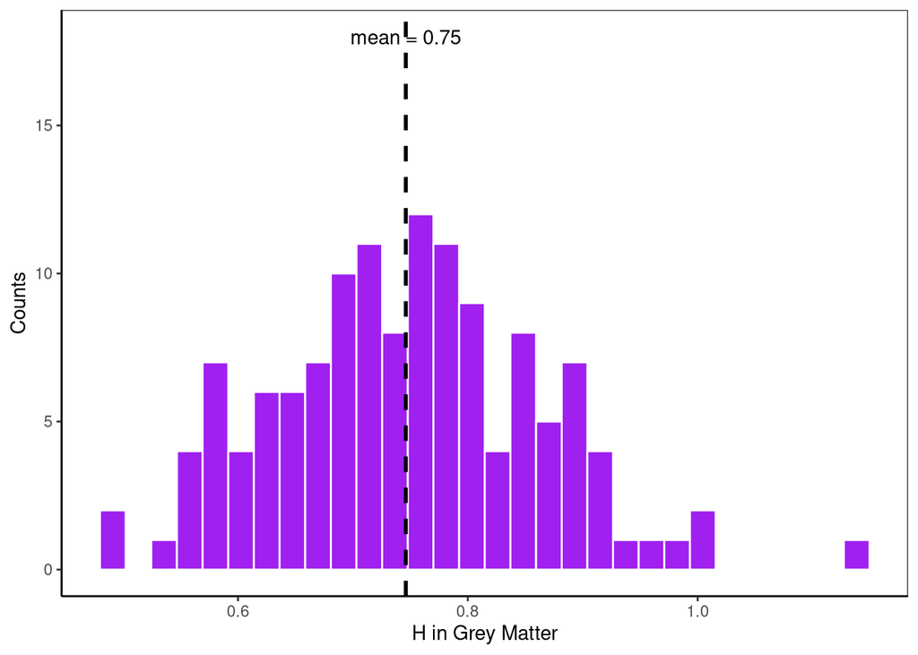

It looks like we *might* have an outlier in H in GM.

|  | Subject ID | Cohort | GA | PMA at Scan | mean FD |
| --- | --- | --- | --- | --- | --- |
| 124 | vil2txxqcb | v02 | 25 | 45.14 | 0.1908303 |

Let’s keep vil2txxqcb at v02 in mind for later…

What about by PMA?

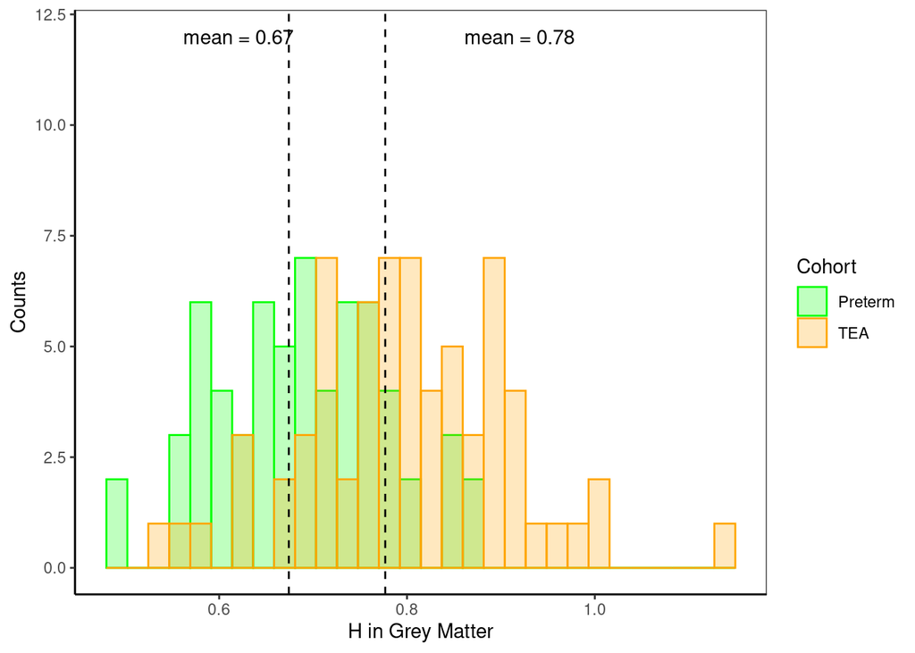

What about our predictor variables?

## Predictor Variables

### FD

Let’s look at mean Framewise Displacement. We will likely have to control for meanFD when looking at H.

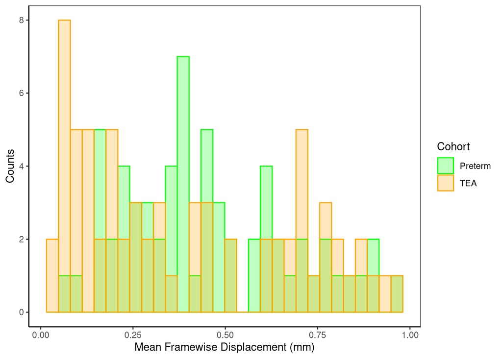

Is framewise displacement different between Preterm and TEA cohorts?

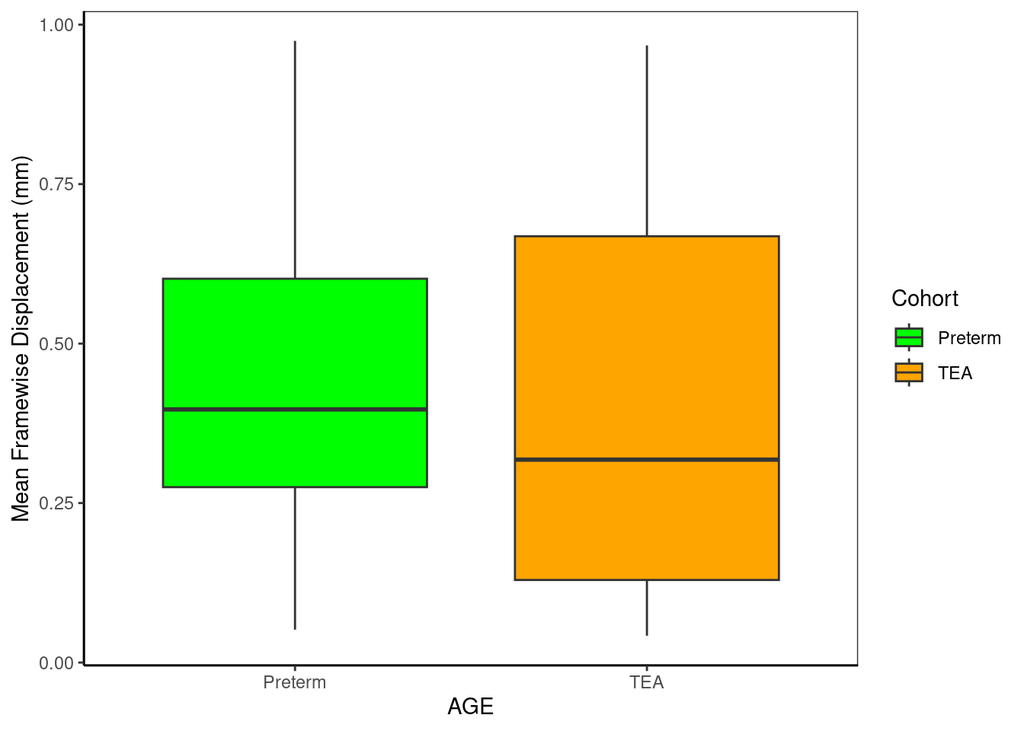

Since the two age groups have a mix of paired and unpaired subjects, we will have to do a linear mixed effects model to compare them.

Although, if we do a paired t.test on just the pairs:

```
##
##  Paired t-test
##
## data:  Pair(FD, AGE)
## t = -15.505, df = 69, p-value < 2.2e-16
## alternative hypothesis: true mean difference is not equal to 0
## 95 percent confidence interval:
##  -1.2337859 -0.9524909
## sample estimates:
## mean difference
##       -1.093138
```

We end up with a p-value of 3.5560587^{-24} and difference of mean 95% CI of -1.2337859, -0.9524909. But we’ll come back to this.

In unpaired subjects:

```
##
##  Paired t-test
##
## data:  Pair(FD, AGE)
## t = -14.772, df = 61, p-value < 2.2e-16
## alternative hypothesis: true mean difference is not equal to 0
## 95 percent confidence interval:
##  -1.2664015 -0.9644224
## sample estimates:
## mean difference
##       -1.115412
```

### Gestational Age

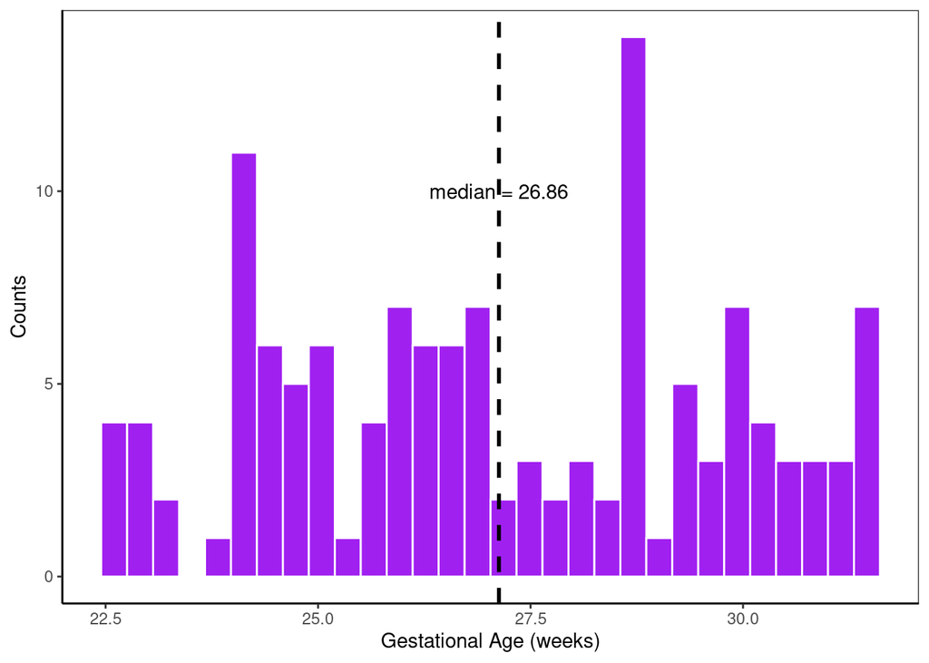

### PMA at Scan

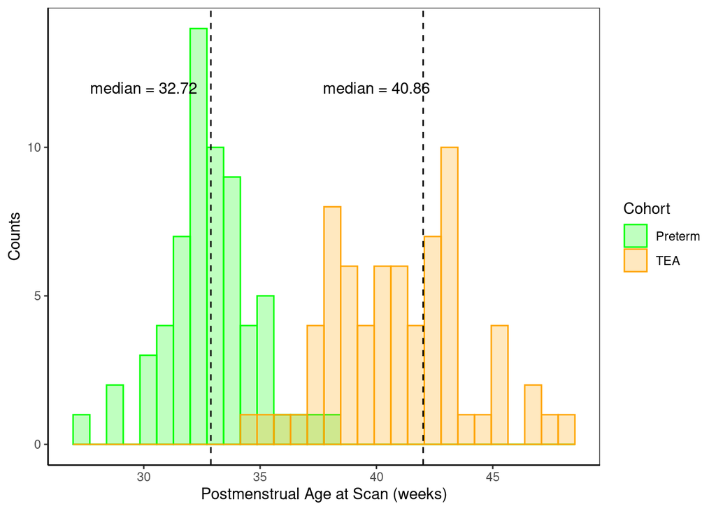

# Basic linear models

Let’s do simple linear regressions of our hypotheses.

## H in GM vs. PMA

```
##
## Call:
## lm(formula = gm_m ~ Scan.Age, data = fullruns)
##
## Residuals:
##       Min        1Q    Median        3Q       Max
## -0.225393 -0.056366  0.005321  0.061121  0.272819
##
## Coefficients:
##             Estimate Std. Error t value Pr(>|t|)
## (Intercept) 0.209512   0.063363   3.307  0.00122 **
## Scan.Age    0.014449   0.001693   8.536 3.15e-14 ***
## ---
## Signif. codes:  0 '***' 0.001 '**' 0.01 '*' 0.05 '.' 0.1 ' ' 1
##
## Residual standard error: 0.09231 on 130 degrees of freedom
## Multiple R-squared:  0.3592, Adjusted R-squared:  0.3542
## F-statistic: 72.86 on 1 and 130 DF,  p-value: 3.154e-14
```

H in GM and PMA definitely seem correlated.

### Plot

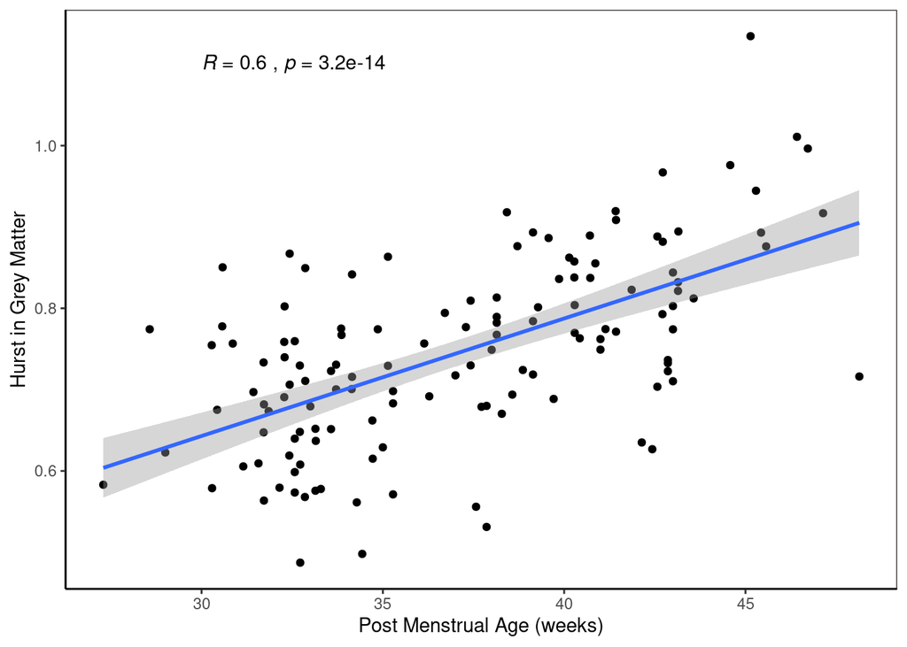

## H in GM vs FD

But maybe there are covariates we need to worry about. FD for example:

```
##
## Call:
## lm(formula = gm_m ~ FD, data = fullruns)
##
## Residuals:
##      Min       1Q   Median       3Q      Max
## -0.25336 -0.08242 -0.01208  0.08126  0.35078
##
## Coefficients:
##             Estimate Std. Error t value Pr(>|t|)
## (Intercept)  0.81536    0.01765  46.191  < 2e-16 ***
## FD          -0.16544    0.03579  -4.622 9.04e-06 ***
## ---
## Signif. codes:  0 '***' 0.001 '**' 0.01 '*' 0.05 '.' 0.1 ' ' 1
##
## Residual standard error: 0.1069 on 130 degrees of freedom
## Multiple R-squared:  0.1411, Adjusted R-squared:  0.1345
## F-statistic: 21.36 on 1 and 130 DF,  p-value: 9.038e-06
```

H in GM and FD seem correlated.

### Plot

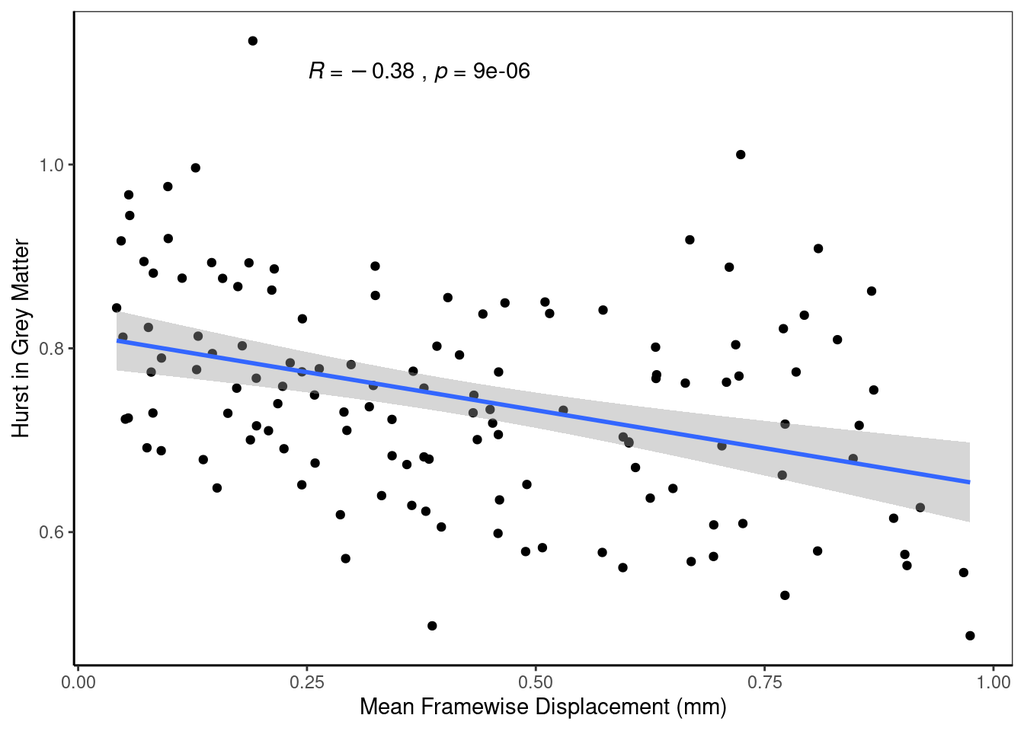

When looking at H, we will definitely want to control for meanFD.

## FD vs PMA

Is mean FD correlated with PMA at Scan?

```
##
## Call:
## lm(formula = FD ~ Scan.Age, data = fullruns)
##
## Residuals:
##      Min       1Q   Median       3Q      Max
## -0.39990 -0.22230 -0.05946  0.21521  0.55230
##
## Coefficients:
##              Estimate Std. Error t value Pr(>|t|)
## (Intercept)  0.756693   0.177247   4.269 3.76e-05 ***
## Scan.Age    -0.009091   0.004735  -1.920    0.057 .
## ---
## Signif. codes:  0 '***' 0.001 '**' 0.01 '*' 0.05 '.' 0.1 ' ' 1
##
## Residual standard error: 0.2582 on 130 degrees of freedom
## Multiple R-squared:  0.02757,    Adjusted R-squared:  0.02009
## F-statistic: 3.686 on 1 and 130 DF,  p-value: 0.05705
```

### Plot

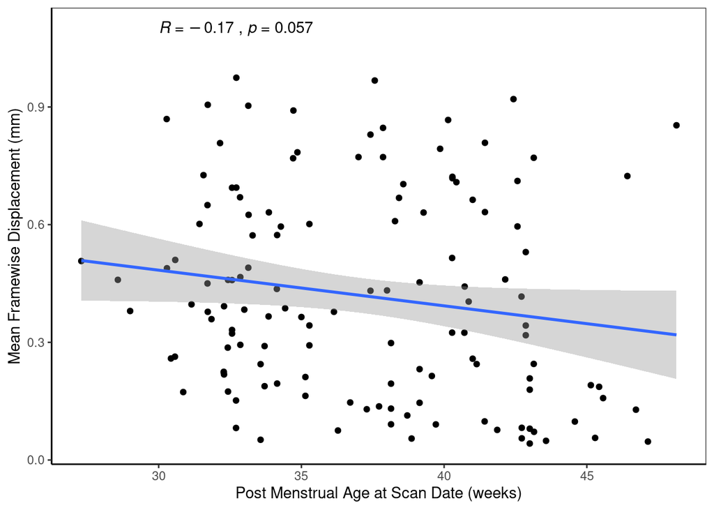

It looks like it is weakly correlated, if at all. But again, this might be something we will want to take into account in our models.

Essentially older babies move less, and moving less leads to higher H.

## H in GM vs Sex

Is there a difference in H in GM with sex?

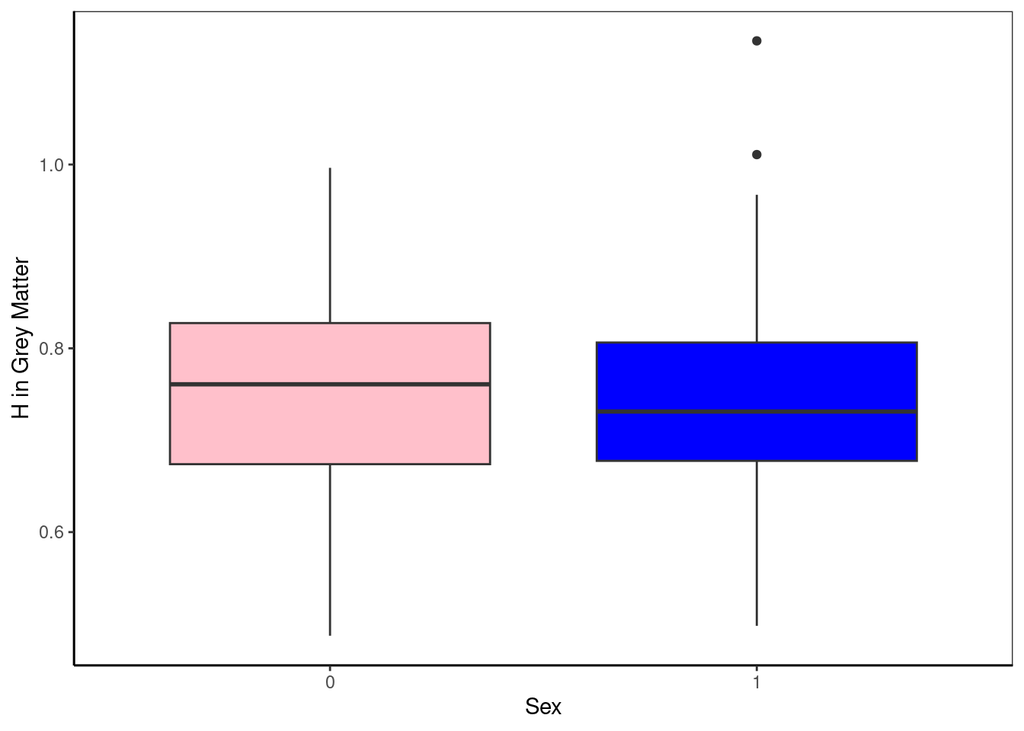

We can perform a t-test with just our TEA cohort:

```
##
##  Welch Two Sample t-test
##
## data:  gm_m by sex
## t = 0.55397, df = 66.835, p-value = 0.5815
## alternative hypothesis: true difference in means between group 0 and group 1 is not equal to 0
## 95 percent confidence interval:
##  -0.03850526  0.06808735
## sample estimates:
## mean in group 0 mean in group 1
##       0.8072372       0.7924462
```

It looks like sex doesn’t make a difference…

## H in GM vs. GA at TEA

Our second hypothesis has to do with H and how old the baby was when they were born.

For example, at TEA, do babies born earlier have lower H values?

```
##
## Call:
## lm(formula = gm_m ~ Birth.age, data = fullruns[fullruns$AGE ==
##     "v02", ])
##
## Residuals:
##      Min       1Q   Median       3Q      Max
## -0.26720 -0.07654 -0.00317  0.07971  0.33728
##
## Coefficients:
##             Estimate Std. Error t value Pr(>|t|)
## (Intercept) 0.766027   0.139362   5.497  6.5e-07 ***
## Birth.age   0.001250   0.005179   0.241     0.81
## ---
## Signif. codes:  0 '***' 0.001 '**' 0.01 '*' 0.05 '.' 0.1 ' ' 1
##
## Residual standard error: 0.1112 on 67 degrees of freedom
## Multiple R-squared:  0.0008694,  Adjusted R-squared:  -0.01404
## F-statistic: 0.0583 on 1 and 67 DF,  p-value: 0.8099
```

### Plot

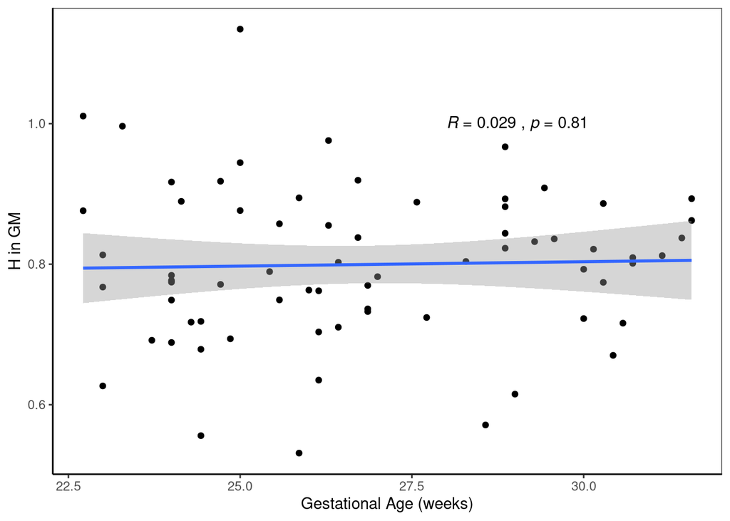

It doesn’t look like it.

If there is a correlation there, it is subtle or being masked by other factors…

## Basic Stats

```r
fullruns
```

```
##     Subject.ID AGE Birth.age Scan.Age         FD brain_volume gm_volume sex
## 1   031rq2m4gn v01  28.57143    30.28 0.86920190     232567.0  50292.00   1
## 2   0ls4ecohie v01  29.85714    32.29 0.21814230     224222.0  54122.00   0
## 3   0qcaac4lmj v01  27.28571    33.29 0.57264170     248580.0  64990.00   0
## 4   1haswxytfj v01  29.28571    31.85 0.35913310     224351.0  50730.00   1
## 5   1ixddssthk v01  31.57143    32.57 0.69413860     158886.0  39227.00   1
## 6   2d0p5srkj9 v01  24.00000    37.86 0.84669460     303555.0  93207.00   0
## 7   31lvdt708c v01  28.71429    32.15 0.80786020     255902.0  60177.00   1
## 8   3ex571ycxe v01  31.57143    32.28 0.22341040     234788.0  54317.00   1
## 9   3le64bcf5w v01  31.57143    32.28 0.22487860     252166.0  58283.00   1
## 10  3n1l6agfcx v01  25.00000    33.71 0.29040670     222832.0  57074.00   0
## 11  4dtv9g8ycl v01  29.42857    31.72 0.90552540     236731.0  51415.00   1
## 12  6rdk820rwn v01  27.71429    34.28 0.59510520     251168.0  65945.00   1
## 13  73oxer7py1 v01  30.42857    32.57 0.33150940     233472.0  57832.00   0
## 14  75kbn9j0fo v01  28.14286    32.71 0.15179030     257958.0  60854.00   1
```

[output cut: 517 more lines]

# Linear Mixed Effects Model

Let’s try a more sophisticated method that will properly take into account paired and unpaired subjects in order to maximize our power. We will use mixed linear effects models and have subjects as random variables. This will also take into account other fixed effects, interactions, etc. etc.

## Missing Data

One issue, however, is with our missing values: is there a non-random reason why some babies weren’t scanned again at TEA?

Let’s look at two specific cohorts: babies scanned at preterm age with TEA scans later on, and those scanned at preterm age without follow-up scans (either due to MRI data quality or they didn’t get scanned)

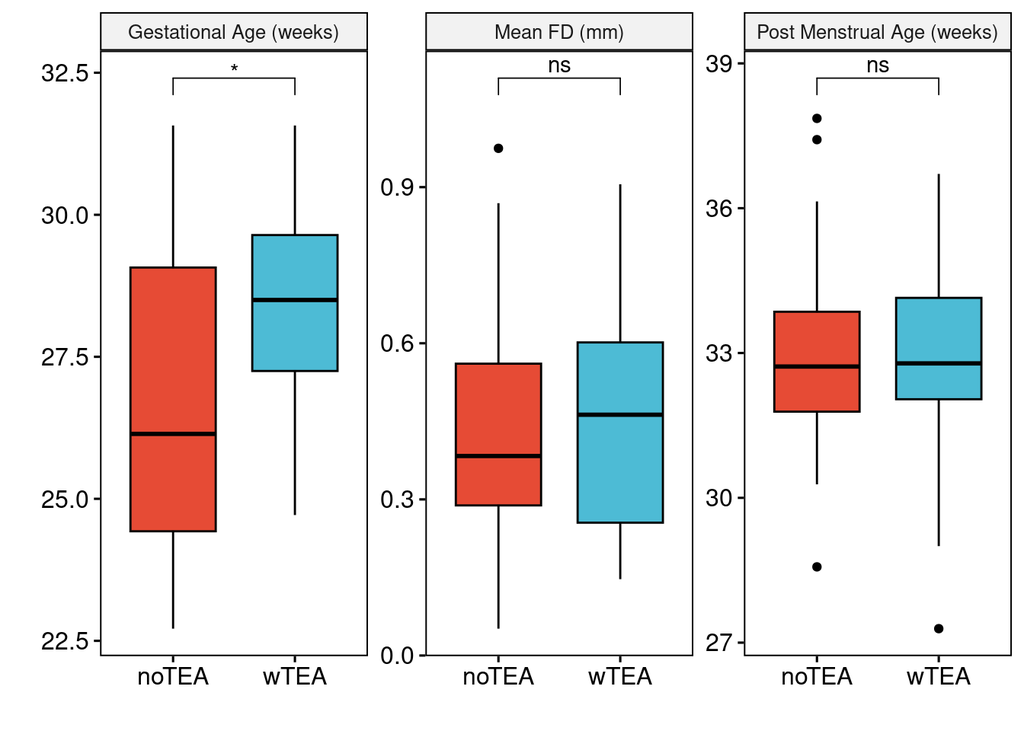

```r
png(file="SupFig1_GAFDPMA.png", width=7, height=4, units="in", res=300)
myplot + stat_pvalue_manual(stat.test, label = "p.adj.signif") + xlab("") + ylab("")
dev.off()
```

It looks like the one thing that distinguishes this group is those without followup data were, on average, born at a younger GA.

We should include GA in our models.

## H in GM vs PMA

Let’s test our first hypothesis.

Focusing first on the GM, let’s build our model:

HinGM ~ PMA + FD + GA + (1|Subject.ID)

Essentially how is H in GM related to PMA. Because we worry about FD, we will include it in our model. Gestational age is included as we worry that our missing values are due to GA (very preterm subjects may be too sick to come back for the TEA scan). Finally, we are treating subjects as random effects: each subject will have random vanriance w.r.t. their H value. This will also take into account repeat measures.

```
## Linear mixed model fit by maximum likelihood  ['lmerMod']
## Formula: gm_m ~ Scan.Age + FD + Birth.age + (1 | Subject.ID)
##    Data: fullruns
##
##      AIC      BIC   logLik deviance df.resid
##   -262.9   -245.6    137.4   -274.9      126
##
## Scaled residuals:
##      Min       1Q   Median       3Q      Max
## -2.44315 -0.70042 -0.05312  0.62816  3.02309
##
## Random effects:
##  Groups     Name        Variance Std.Dev.
##  Subject.ID (Intercept) 0.000000 0.00000
##  Residual               0.007297 0.08542
## Number of obs: 132, groups:  Subject.ID, 97
##
## Fixed effects:
##              Estimate Std. Error t value
## (Intercept)  0.209154   0.105692   1.979
## Scan.Age     0.013510   0.001598   8.453
## FD          -0.127269   0.029080  -4.377
## Birth.age    0.003265   0.002927   1.116
##
## Correlation of Fixed Effects:
##           (Intr) Scn.Ag FD
## Scan.Age  -0.663
## FD        -0.152  0.157
## Birth.age -0.806  0.111 -0.068
## optimizer (nloptwrap) convergence code: 0 (OK)
## boundary (singular) fit: see help('isSingular')
```

This looks like a lot, but essentially it is saying H = 0.209 + 0.014xPMA -0.127xFD + 0.003xGA

Let’s try GA=25, PMA=40, FD=0.5:

H = 0.209 + 0.014x40 -0.127x0.5 + 0.003x25

H = 0.768

Which agrees well with what we saw before.

Let’s test our main hypothesis then: is H affected by PMA?

| npar | AIC | BIC | logLik | deviance | Chisq | Df | Pr(>Chisq) |
| --- | --- | --- | --- | --- | --- | --- | --- |
| 5 | -207.8 | -193.4 | 108.9 | -217.8 | NA | NA | NA |
| 6 | -262.9 | -245.6 | 137.4 | -274.9 | 57.1 | 1 | 4.127751e-14 |

Yes, very much so.

FD?

| npar | AIC | BIC | logLik | deviance | Chisq | Df | Pr(>Chisq) |
| --- | --- | --- | --- | --- | --- | --- | --- |
| 5 | -247.0 | -232.6 | 128.5 | -257.0 | NA | NA | NA |
| 6 | -262.9 | -245.6 | 137.4 | -274.9 | 17.9 | 1 | 2.345419e-05 |

Yes.

And GA?

| npar | AIC | BIC | logLik | deviance | Chisq | Df | Pr(>Chisq) |
| --- | --- | --- | --- | --- | --- | --- | --- |
| 5 | -263.6 | -249.2 | 136.8 | -273.6 | NA | NA | NA |
| 6 | -262.9 | -245.6 | 137.4 | -274.9 | 1.2 | 1 | 0.2657262 |

Not so much. But we should keep it in as we worry about missing values.

## GM and WM

```
## Linear mixed model fit by maximum likelihood  ['lmerMod']
## Formula: H ~ Scan.Age * ROI + Birth.age + FD + (1 + ROI | Subject.ID)
##    Data: matterdata
##
##      AIC      BIC   logLik deviance df.resid
##   -878.3   -818.6    454.1   -908.3      381
##
## Scaled residuals:
##      Min       1Q   Median       3Q      Max
## -2.79729 -0.46137 -0.02917  0.37389  2.97826
##
## Random effects:
##  Groups     Name        Variance  Std.Dev.  Corr
##  Subject.ID (Intercept) 3.863e-03 0.0621560
##             ROIvent_m   2.076e-05 0.0045566 1.00
##             ROIwm_m     9.279e-08 0.0003046 1.00 1.00
##  Residual               3.988e-03 0.0631467
## Number of obs: 396, groups:  Subject.ID, 97
##
## Fixed effects:
##                     Estimate Std. Error t value
## (Intercept)         0.085718   0.095614   0.896
## Scan.Age            0.014994   0.001304  11.499
## ROIvent_m           0.063856   0.061319   1.041
## ROIwm_m             0.037658   0.061297   0.614
## Birth.age           0.005119   0.002904   1.763
## FD                 -0.093139   0.018044  -5.162
## Scan.Age:ROIvent_m -0.001945   0.001638  -1.188
## Scan.Age:ROIwm_m   -0.001354   0.001638  -0.827
##
## Correlation of Fixed Effects:
##              (Intr) Scn.Ag ROIvn_ ROIwm_ Brth.g FD     Scn.Ag:ROIv_
## Scan.Age     -0.557
## ROIvent_m    -0.318  0.612
## ROIwm_m      -0.320  0.622  0.500
## Birth.age    -0.849  0.050  0.005  0.000
## FD           -0.096  0.113  0.000  0.000 -0.050
## Scn.Ag:ROIv_  0.317 -0.617 -0.992 -0.496 -0.005  0.000
## Scn.Ag:ROIw_  0.318 -0.627 -0.496 -0.992  0.000  0.000  0.500
## optimizer (nloptwrap) convergence code: 0 (OK)
## boundary (singular) fit: see help('isSingular')
```

```r
ventPredict <- H_matterpredict %>% filter(group == "vent_m")
ventData <- roidata %>% filter(ROI == "vent_m")
ventplot <- ggplot() + geom_point(data=ventData, aes(Scan.Age, H), shape=1) +
  geom_smooth(data=ventData, aes(Scan.Age, H), method="lm", colour="grey", size=0.5, alpha=0.3) +
  geom_ribbon(data=ventPredict, aes(x=x,ymin=conf.low, ymax=conf.high), fill="magenta1",alpha=0.15,)+
  geom_line(data=ventPredict, aes(x=x, y = conf.high), colour = "magenta1", linetype = "dashed") +
  geom_line(data=ventPredict, aes(x=x, y = conf.low), colour = "magenta1", linetype = "dashed") +
  geom_line(data=ventPredict, aes(x,predicted), color="magenta1") +
  labs(x='', y='') +
  ggtitle("Ventricles") +
  theme(plot.title = element_text(size=10))+
  ggeasy::easy_center_title() +
  ylim(0.5,1) +
  theme(legend.position = "none") + theme(panel.grid.major = element_blank(), panel.grid.minor = element_blank(),
panel.background = element_blank(), axis.line = element_line(colour = "black"))
```

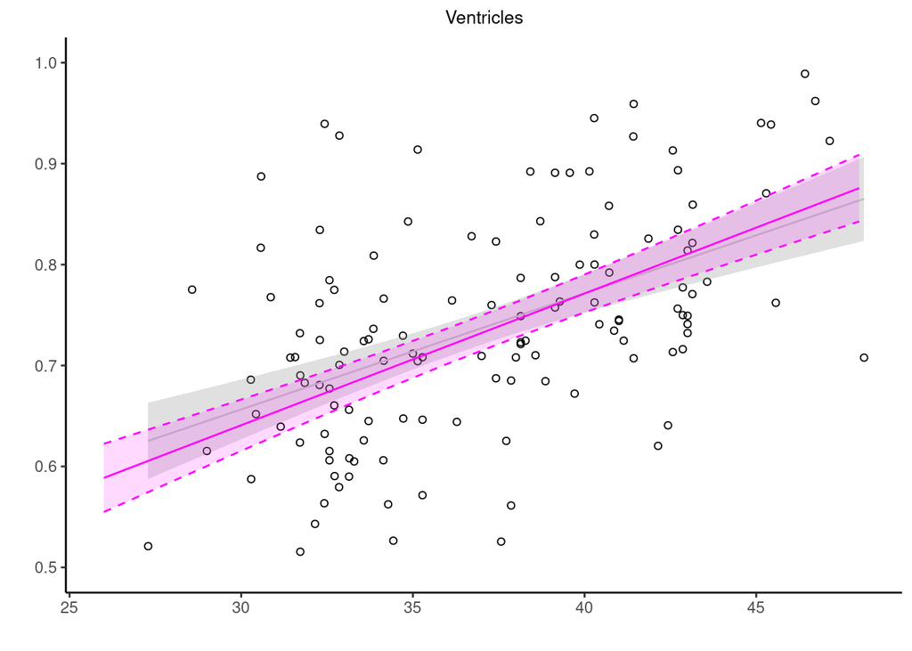

```r
ventplot
```

```r
WMPredict <- H_matterpredict %>% filter(group == "wm_m")
WMData <- roidata %>% filter(ROI == "wm_m")
wmplot <- ggplot() + geom_point(data=WMData, aes(Scan.Age, H), shape=1) +
  geom_smooth(data=WMData, aes(Scan.Age, H), method="lm", colour="grey", size=0.5, alpha=0.3) +
  geom_ribbon(data=WMPredict, aes(x=x,ymin=conf.low, ymax=conf.high), fill="#cab2d6",alpha=0.15,)+
  geom_line(data=WMPredict, aes(x=x, y = conf.high), colour = "#cab2d6", linetype = "dashed") +
  geom_line(data=WMPredict, aes(x=x, y = conf.low), colour = "#cab2d6", linetype = "dashed") +
  geom_line(data=WMPredict, aes(x,predicted), color="#cab2d6") +
  labs(x='', y='') +
  ggtitle("White Matter") +
  theme(plot.title = element_text(size=10))+
  ggeasy::easy_center_title() +
  ylim(0.5,1) +
  theme(legend.position = "none") + theme(panel.grid.major = element_blank(), panel.grid.minor = element_blank(),
panel.background = element_blank(), axis.line = element_line(colour = "black"))
```

```r
GMPredict <- H_matterpredict %>% filter(group == "gm_m")
GMData <- roidata %>% filter(ROI == "gm_m")
gmplot <- ggplot() + geom_point(data=GMData, aes(Scan.Age, H), shape=1) +
  geom_smooth(data=GMData, aes(Scan.Age, H), method="lm", colour="grey", size=0.5, alpha=0.3) +
  geom_ribbon(data=GMPredict, aes(x=x,ymin=conf.low, ymax=conf.high), fill="#6a3d9a",alpha=0.15,)+
  geom_line(data=GMPredict, aes(x=x, y = conf.high), colour = "#6a3d9a", linetype = "dashed") +
  geom_line(data=GMPredict, aes(x=x, y = conf.low), colour = "#6a3d9a", linetype = "dashed") +
  geom_line(data=GMPredict, aes(x,predicted), color="#6a3d9a") +
  labs(x='', y='') +
  ggtitle("Grey Matter") +
  theme(plot.title = element_text(size=10))+
  ggeasy::easy_center_title() +
  ylim(0.5,1) +
  theme(legend.position = "none") + theme(panel.grid.major = element_blank(), panel.grid.minor = element_blank(),
panel.background = element_blank(), axis.line = element_line(colour = "black"))
```

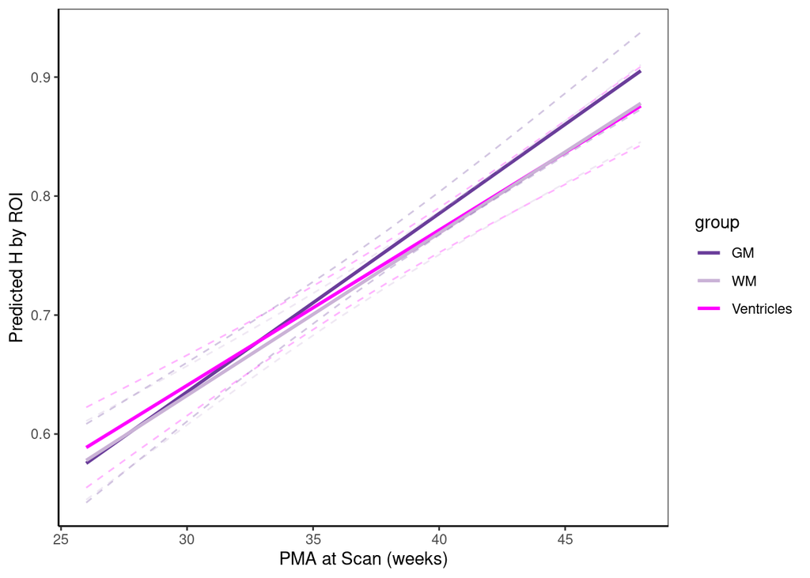

```r
matterplot
```

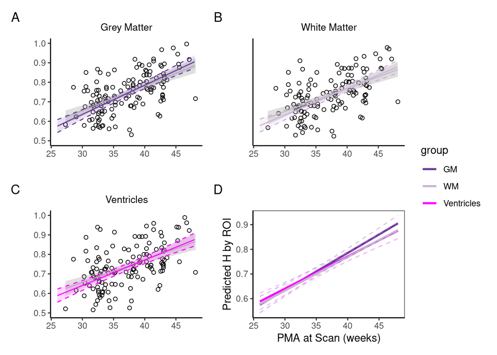

```r
patchworkmatter = gmplot + wmplot + ventplot + matterplot + #guide_area() +
  plot_layout(ncol = 2, guides= 'collect')
patchworkmatter[[2]] = patchworkmatter[[2]] + theme(axis.text.y = element_blank(),
                                        axis.ticks.y = element_blank(),
                                        axis.title.y = element_blank())

patchworkmatter + plot_annotation(tag_levels = 'A')
```

```r
png(file="Figure4_tissueplots_annotated.png", width=7, height=4, units="in", res=300)
patchworkmatter + plot_annotation(tag_levels = 'A')
dev.off()
```

```r
gmmodel <- roidata %>% filter(ROI == "gm_m") %>% lmer(H ~ Scan.Age + Birth.age + FD + (1|Subject.ID), REML=FALSE, data=.)
summary(gmmodel)
```

```
## Linear mixed model fit by maximum likelihood  ['lmerMod']
## Formula: H ~ Scan.Age + Birth.age + FD + (1 | Subject.ID)
##    Data: .
##
##      AIC      BIC   logLik deviance df.resid
##   -262.9   -245.6    137.4   -274.9      126
##
## Scaled residuals:
##      Min       1Q   Median       3Q      Max
## -2.44315 -0.70042 -0.05312  0.62816  3.02309
##
## Random effects:
##  Groups     Name        Variance Std.Dev.
##  Subject.ID (Intercept) 0.000000 0.00000
##  Residual               0.007297 0.08542
## Number of obs: 132, groups:  Subject.ID, 97
##
## Fixed effects:
##              Estimate Std. Error t value
## (Intercept)  0.209154   0.105692   1.979
## Scan.Age     0.013510   0.001598   8.453
## Birth.age    0.003265   0.002927   1.116
## FD          -0.127269   0.029080  -4.377
##
## Correlation of Fixed Effects:
##           (Intr) Scn.Ag Brth.g
## Scan.Age  -0.663
## Birth.age -0.806  0.111
## FD        -0.152  0.157 -0.068
## optimizer (nloptwrap) convergence code: 0 (OK)
## boundary (singular) fit: see help('isSingular')
```

```r
r.squaredGLMM(gmmodel)
```

```
##            R2m       R2c
## [1,] 0.4447363 0.4447363
```

```r
wmmodel <- roidata %>% filter(ROI == "wm_m") %>% lmer(H ~ Scan.Age + Birth.age + FD + (1|Subject.ID), REML=FALSE, data=.)
summary(wmmodel)
```

```
## Linear mixed model fit by maximum likelihood  ['lmerMod']
## Formula: H ~ Scan.Age + Birth.age + FD + (1 | Subject.ID)
##    Data: .
##
##      AIC      BIC   logLik deviance df.resid
##   -262.5   -245.2    137.3   -274.5      126
##
## Scaled residuals:
##      Min       1Q   Median       3Q      Max
## -2.33375 -0.65965 -0.09324  0.57285  2.75760
##
## Random effects:
##  Groups     Name        Variance Std.Dev.
##  Subject.ID (Intercept) 0.000000 0.00000
##  Residual               0.007317 0.08554
## Number of obs: 132, groups:  Subject.ID, 97
##
## Fixed effects:
##              Estimate Std. Error t value
## (Intercept)  0.231208   0.105840   2.185
## Scan.Age     0.012274   0.001600   7.669
## Birth.age    0.003496   0.002931   1.193
## FD          -0.115402   0.029120  -3.963
##
## Correlation of Fixed Effects:
##           (Intr) Scn.Ag Brth.g
## Scan.Age  -0.663
## Birth.age -0.806  0.111
## FD        -0.152  0.157 -0.068
## optimizer (nloptwrap) convergence code: 0 (OK)
## boundary (singular) fit: see help('isSingular')
```

```r
r.squaredGLMM(wmmodel)
```

```
##            R2m       R2c
## [1,] 0.3969004 0.3969004
```

### Estimated marginal means

```
##  Scan.Age ROI    emmean      SE  df lower.CL upper.CL
##      32.7 gm_m    0.676 0.01042 153    0.655    0.696
##      40.9 gm_m    0.799 0.00989 139    0.779    0.818
##      32.7 vent_m  0.676 0.01076 152    0.655    0.697
##      40.9 vent_m  0.783 0.01024 138    0.763    0.803
##      32.7 wm_m    0.669 0.01044 153    0.649    0.690
##      40.9 wm_m    0.781 0.00992 139    0.762    0.801
##
## Degrees-of-freedom method: kenward-roger
## Confidence level used: 0.95
```

```r
tissueslopes <- emtrends(tissue.model, ~ ROI, var="Scan.Age")
tidytissueslopes <- tidy(tissueslopes, conf.int = T) %>% dplyr::select(ROI, Scan.Age.trend, p.value, conf.low, conf.high)
```

```r
tissueslopes %>% contrast("revpairwise") %>% tidy(.)
```

```
## # A tibble: 3 × 8
##   term  contrast      null.value  estimate std.error    df statistic adj.p.value
##   <chr> <chr>              <dbl>     <dbl>     <dbl> <dbl>     <dbl>       <dbl>
## 1 ROI   vent_m - gm_m          0 -0.00195    0.00168  215.    -1.16        0.478
## 2 ROI   wm_m - gm_m            0 -0.00135    0.00167  215.    -0.808       0.698
## 3 ROI   wm_m - vent_m          0  0.000592   0.00168  215.     0.353       0.934
```

```r
fullruns %>% filter(AGE == "v01") %>% with(t.test(gm_m, wm_m, paired=TRUE, alternative = "two.sided"))
```

```
##
##  Paired t-test
##
## data:  gm_m and wm_m
## t = 3.1897, df = 62, p-value = 0.002235
## alternative hypothesis: true mean difference is not equal to 0
## 95 percent confidence interval:
##  0.002228117 0.009709248
## sample estimates:
## mean difference
##     0.005968683
```

```r
fullruns %>% select(c(Subject.ID, AGE, gm_m, wm_m)) %>% pivot_longer(ends_with('_m'), names_to = 'ROI', values_to = 'H') %>% filter(AGE == "v01") %>% cohens_d(H ~ ROI, paired = TRUE)
```

```
## # A tibble: 1 × 7
##   .y.   group1 group2 effsize    n1    n2 magnitude
## * <chr> <chr>  <chr>    <dbl> <int> <int> <ord>
## 1 H     gm_m   wm_m     0.402    63    63 small
```

```r
fullruns %>% filter(AGE == "v02") %>% with(t.test(gm_m, wm_m, paired=TRUE, alternative = "two.sided"))
```

```
##
##  Paired t-test
##
## data:  gm_m and wm_m
## t = 10.105, df = 68, p-value = 3.559e-15
## alternative hypothesis: true mean difference is not equal to 0
## 95 percent confidence interval:
##  0.01494431 0.02229885
## sample estimates:
## mean difference
##      0.01862158
```

```r
fullruns %>% select(c(Subject.ID, AGE, gm_m, wm_m)) %>% pivot_longer(ends_with('_m'), names_to = 'ROI', values_to = 'H') %>% filter(AGE == "v02") %>% cohens_d(H ~ ROI, paired = TRUE)
```

```
## # A tibble: 1 × 7
##   .y.   group1 group2 effsize    n1    n2 magnitude
## * <chr> <chr>  <chr>    <dbl> <int> <int> <ord>
## 1 H     gm_m   wm_m      1.22    69    69 large
```

## H vs PMA across ROIs

What about across our ROIs?

[figure not shown]

ROIs

Now our model will look like:

H ~ PMA*ROI + FD + GA + (1+ROI|Subject.ID)

Essentially we think that each ROI might have a different H vs PMA response, both in terms of the intercept, and its slope.

```r
rsndata <- roidata %>% filter(ROI != "gm_m" & ROI != "wm_m" & ROI != "vent_m" & ROI != "temporal_lobe_m" & ROI != "posterior_m")
```

```
## Linear mixed model fit by maximum likelihood  ['lmerMod']
## Formula: H ~ Scan.Age * ROI + Birth.age + FD + (1 + ROI | Subject.ID)
##    Data: rsndata
##
##      AIC      BIC   logLik deviance df.resid
##  -2508.1  -2172.8   1320.0  -2640.1     1122
##
## Scaled residuals:
##     Min      1Q  Median      3Q     Max
## -3.0986 -0.5464 -0.0149  0.5356  3.3918
##
## Random effects:
##  Groups     Name            Variance  Std.Dev. Corr
##  Subject.ID (Intercept)     5.096e-03 0.071387
##             ROIcerebellum_m 1.279e-04 0.011308 -1.00
##             ROIfrontal_m    1.144e-05 0.003382 -0.97  0.97
##             ROIhindbrain_m  4.604e-05 0.006785 -0.99  0.99  0.92
##             ROIlateral_l_m  3.083e-05 0.005552 -0.91  0.91  0.78  0.96
##             ROIlateral_r_m  9.893e-06 0.003145  0.08 -0.08 -0.32  0.07  0.34
##             ROImotor_m      8.515e-06 0.002918  0.63 -0.63 -0.43 -0.74 -0.90
##             ROIsalient_m    1.128e-06 0.001062  0.05 -0.05  0.20 -0.20 -0.46
##             ROIvisual_m     9.397e-05 0.009694  0.90 -0.90 -0.98 -0.82 -0.63
##  Residual                   5.177e-03 0.071952
##
##
##
##
##
##
##
##  -0.72
##  -0.99  0.80
##   0.52  0.23 -0.40
##
## Number of obs: 1188, groups:  Subject.ID, 97
##
## Fixed effects:
##                            Estimate Std. Error t value
## (Intercept)               0.0461705  0.0955210   0.483
## Scan.Age                  0.0155192  0.0014022  11.068
## ROIcerebellum_m           0.0608080  0.0699127   0.870
## ROIfrontal_m              0.1307618  0.0698517   1.872
## ROIhindbrain_m            0.0539121  0.0698713   0.772
## ROIlateral_l_m           -0.0171389  0.0698711  -0.245
## ROIlateral_r_m           -0.0560667  0.0698674  -0.802
## ROImotor_m               -0.1323805  0.0698583  -1.895
## ROIsalient_m              0.0551026  0.0698472   0.789
## ROIvisual_m              -0.1655078  0.0699261  -2.367
## Birth.age                 0.0058495  0.0028707   2.038
## FD                       -0.0752523  0.0130380  -5.772
## Scan.Age:ROIcerebellum_m -0.0025418  0.0018675  -1.361
## Scan.Age:ROIfrontal_m    -0.0042813  0.0018660  -2.294
## Scan.Age:ROIhindbrain_m  -0.0017151  0.0018665  -0.919
## Scan.Age:ROIlateral_l_m  -0.0001975  0.0018665  -0.106
## Scan.Age:ROIlateral_r_m   0.0010347  0.0018665   0.554
## Scan.Age:ROImotor_m       0.0040314  0.0018662   2.160
## Scan.Age:ROIsalient_m    -0.0023564  0.0018659  -1.263
## Scan.Age:ROIvisual_m      0.0044947  0.0018679   2.406
## optimizer (nloptwrap) convergence code: 0 (OK)
## boundary (singular) fit: see help('isSingular')
```

Is H statistically significant across PMA in some of these ROIs?

| npar | AIC | BIC | logLik | deviance | Chisq | Df | Pr(>Chisq) |
| --- | --- | --- | --- | --- | --- | --- | --- |
| 57 | -2038.7 | -1749.1 | 1076.3 | -2152.7 | NA | NA | NA |
| 66 | -2508.1 | -2172.8 | 1320.0 | -2640.1 | 487.4 | 9 | 2.827719e-99 |

Yes, they are.

But which ones? And how much (slope)?

```r
VisualPredict <- Hpredict %>% filter(group == "visual_m")
VisualData <- roidata %>% filter(ROI == "visual_m")
visplot <- ggplot() + geom_point(data=VisualData, aes(Scan.Age, H), shape=1) +
  geom_smooth(data=VisualData, aes(Scan.Age, H), method="lm", colour="grey", size=0.5, alpha=0.3) +
  geom_ribbon(data=VisualPredict, aes(x=x,ymin=conf.low, ymax=conf.high), fill="#a6cee3",alpha=0.15,)+
  geom_line(data=VisualPredict, aes(x=x, y = conf.high), colour = "#a6cee3", linetype = "dashed") +
  geom_line(data=VisualPredict, aes(x=x, y = conf.low), colour = "#a6cee3", linetype = "dashed") +
  geom_line(data=VisualPredict, aes(x,predicted), color="#a6cee3") +
  labs(x='', y='') +
  ggtitle("Visual") +
  theme(plot.title = element_text(size=10))+
  ggeasy::easy_center_title() +
  ylim(0.5,1.3) +
  theme(legend.position = "none") + theme(panel.grid.major = element_blank(), panel.grid.minor = element_blank(),
panel.background = element_blank(), axis.line = element_line(colour = "black"))
```

```r
MotorPredict <- Hpredict %>% filter(group == "motor_m")
MotorData <- roidata %>% filter(ROI == "motor_m")
motorplot <- ggplot() + geom_point(data=MotorData, aes(Scan.Age, H), shape=1) +
  geom_smooth(data=MotorData, aes(Scan.Age, H), method="lm", colour="grey", size=0.5, alpha=0.3) +
  geom_ribbon(data=MotorPredict, aes(x=x,ymin=conf.low, ymax=conf.high), fill="#1f78b4",alpha=0.15,)+
  geom_line(data=MotorPredict, aes(x=x, y = conf.high), colour = "#1f78b4", linetype = "dashed") +
  geom_line(data=MotorPredict, aes(x=x, y = conf.low), colour = "#1f78b4", linetype = "dashed") +
  geom_line(data=MotorPredict, aes(x,predicted), color="#1f78b4") +
  labs(x='', y='') +
    ggtitle("Motor") +
  ggeasy::easy_center_title() +
  theme(plot.title = element_text(size=10))+
  ylim(0.5,1.3) +
  theme(legend.position = "none") + theme(panel.grid.major = element_blank(), panel.grid.minor = element_blank(),
panel.background = element_blank(), axis.line = element_line(colour = "black"))
```

```r
LateralRPredict <- Hpredict %>% filter(group == "lateral_r_m")
LateralRData <- roidata %>% filter(ROI == "lateral_r_m")
latrplot <- ggplot() + geom_point(data=LateralRData, aes(Scan.Age, H), shape=1) +
  geom_smooth(data=LateralRData, aes(Scan.Age, H), method="lm", colour="grey", size=0.5, alpha=0.3) +
  geom_ribbon(data=LateralRPredict, aes(x=x,ymin=conf.low, ymax=conf.high), fill="#b2df8a",alpha=0.15,)+
  geom_line(data=LateralRPredict, aes(x=x, y = conf.high), colour = "#b2df8a", linetype = "dashed") +
  geom_line(data=LateralRPredict, aes(x=x, y = conf.low), colour = "#b2df8a", linetype = "dashed") +
  geom_line(data=LateralRPredict, aes(x,predicted), color="#b2df8a") +
  labs(x='', y='') +
    ggtitle("Lateral Right") +
  ggeasy::easy_center_title() +
    theme(plot.title = element_text(size=10))+
  ylim(0.5,1.3) +
  theme(legend.position = "none") + theme(panel.grid.major = element_blank(), panel.grid.minor = element_blank(),
panel.background = element_blank(), axis.line = element_line(colour = "black"))
```

```r
AuditoryPredict <- Hpredict %>% filter(group == "auditory_m")
AuditoryData <- roidata %>% filter(ROI == "auditory_m")
auditoryplot <- ggplot() + geom_point(data=AuditoryData, aes(Scan.Age, H), shape=1) +
  geom_smooth(data=AuditoryData, aes(Scan.Age, H), method="lm", colour="grey", size=0.5, alpha=0.3) +
  geom_ribbon(data=AuditoryPredict, aes(x=x,ymin=conf.low, ymax=conf.high), fill="#33a02c",alpha=0.15,)+
  geom_line(data=AuditoryPredict, aes(x=x, y = conf.high), colour = "#33a02c", linetype = "dashed") +
  geom_line(data=AuditoryPredict, aes(x=x, y = conf.low), colour = "#33a02c", linetype = "dashed") +
  geom_line(data=AuditoryPredict, aes(x,predicted), color="#33a02c") +
  labs(x='', y='') +
    ggtitle("Auditory") +
  ggeasy::easy_center_title() +
    theme(plot.title = element_text(size=10))+
  ylim(0.5,1.3) +
  theme(legend.position = "none") + theme(panel.grid.major = element_blank(), panel.grid.minor = element_blank(),
panel.background = element_blank(), axis.line = element_line(colour = "black"))
```

```r
LateralLPredict <- Hpredict %>% filter(group == "lateral_l_m")
LateralLData <- roidata %>% filter(ROI == "lateral_l_m")
latlplot <- ggplot() + geom_point(data=LateralLData, aes(Scan.Age, H), shape=1) +
  geom_smooth(data=LateralLData, aes(Scan.Age, H), method="lm", colour="grey", size=0.5, alpha=0.3) +
  geom_ribbon(data=LateralLPredict, aes(x=x,ymin=conf.low, ymax=conf.high), fill="#fb9a99",alpha=0.15,)+
  geom_line(data=LateralLPredict, aes(x=x, y = conf.high), colour = "#fb9a99", linetype = "dashed") +
  geom_line(data=LateralLPredict, aes(x=x, y = conf.low), colour = "#fb9a99", linetype = "dashed") +
  geom_line(data=LateralLPredict, aes(x,predicted), color="#fb9a99") +
  labs(x='', y='') +
    ggtitle("Lateral Left") +
  theme(plot.title = element_text(size=10))+
  ggeasy::easy_center_title() +
  ylim(0.5,1.3) +
  theme(legend.position = "none") + theme(panel.grid.major = element_blank(), panel.grid.minor = element_blank(),
panel.background = element_blank(), axis.line = element_line(colour = "black"))
```

```r
CerebellumPredict <- Hpredict %>% filter(group == "cerebellum_m")
CerebellumData <- roidata %>% filter(ROI == "cerebellum_m")
cerebellumplot <- ggplot() + geom_point(data=CerebellumData, aes(Scan.Age, H), shape=1) +
  geom_smooth(data=CerebellumData, aes(Scan.Age, H), method="lm", colour="grey", size=0.5, alpha=0.3) +
  geom_ribbon(data=CerebellumPredict, aes(x=x,ymin=conf.low, ymax=conf.high), fill="#e31a1c",alpha=0.15,)+
  geom_line(data=CerebellumPredict, aes(x=x, y = conf.high), colour = "#e31a1c", linetype = "dashed") +
  geom_line(data=CerebellumPredict, aes(x=x, y = conf.low), colour = "#e31a1c", linetype = "dashed") +
  geom_line(data=CerebellumPredict, aes(x,predicted), color="#e31a1c") +
  labs(x='', y='') +
    ggtitle("Cerebellum") +
  ggeasy::easy_center_title() +
    theme(plot.title = element_text(size=10))+
  ylim(0.5,1.3) +
  theme(legend.position = "none") + theme(panel.grid.major = element_blank(), panel.grid.minor = element_blank(),
panel.background = element_blank(), axis.line = element_line(colour = "black"))
```

```r
FrontalPredict <- Hpredict %>% filter(group == "frontal_m")
FrontalData <- roidata %>% filter(ROI == "frontal_m")
frontplot <- ggplot() + geom_point(data=FrontalData, aes(Scan.Age, H), shape=1) +
  geom_smooth(data=FrontalData, aes(Scan.Age, H), method="lm", colour="grey", size=0.5, alpha=0.3) +
  geom_ribbon(data=FrontalPredict, aes(x=x,ymin=conf.low, ymax=conf.high), fill="#fdbf6f",alpha=0.15,)+
  geom_line(data=FrontalPredict, aes(x=x, y = conf.high), colour = "#fdbf6f", linetype = "dashed") +
  geom_line(data=FrontalPredict, aes(x=x, y = conf.low), colour = "#fdbf6f", linetype = "dashed") +
  geom_line(data=FrontalPredict, aes(x,predicted), color="#fdbf6f") +
  labs(x='', y='') +
    ggtitle("Frontal") +
    theme(plot.title = element_text(size=10))+
  ggeasy::easy_center_title() +
  ylim(0.5,1.3) +
  theme(legend.position = "none") + theme(panel.grid.major = element_blank(), panel.grid.minor = element_blank(),
panel.background = element_blank(), axis.line = element_line(colour = "black"))
```

```r
HindbrainPredict <- Hpredict %>% filter(group == "hindbrain_m")
HindbrainData <- roidata %>% filter(ROI == "hindbrain_m")
hindplot <- ggplot() + geom_point(data=HindbrainData, aes(Scan.Age, H), shape=1) +
  geom_smooth(data=HindbrainData, aes(Scan.Age, H), method="lm", colour="grey", size=0.5, alpha=0.3) +
  geom_ribbon(data=HindbrainPredict, aes(x=x,ymin=conf.low, ymax=conf.high), fill="#ff7f00",alpha=0.15,)+
  geom_line(data=HindbrainPredict, aes(x=x, y = conf.high), colour = "#ff7f00", linetype = "dashed") +
  geom_line(data=HindbrainPredict, aes(x=x, y = conf.low), colour = "#ff7f00", linetype = "dashed") +
  geom_line(data=HindbrainPredict, aes(x,predicted), color="#ff7f00") +
  labs(x='', y='') +
    ggtitle("Hindbrain") +
  ggeasy::easy_center_title() +
    theme(plot.title = element_text(size=10))+
  ylim(0.5,1.3) +
  theme(legend.position = "none") + theme(panel.grid.major = element_blank(), panel.grid.minor = element_blank(),
panel.background = element_blank(), axis.line = element_line(colour = "black"))
```

```r
SalientPredict <- Hpredict %>% filter(group == "salient_m")
SalientData <- roidata %>% filter(ROI == "salient_m")
salientplot <- ggplot() + geom_point(data=SalientData, aes(Scan.Age, H), shape=1) +
  geom_smooth(data=SalientData, aes(Scan.Age, H), method="lm", colour="grey", size=0.5, alpha=0.3) +
  geom_ribbon(data=SalientPredict, aes(x=x,ymin=conf.low, ymax=conf.high), fill="#ffff00",alpha=0.15,)+
  geom_line(data=SalientPredict, aes(x=x, y = conf.high), colour = "#ffff00", linetype = "dashed") +
  geom_line(data=SalientPredict, aes(x=x, y = conf.low), colour = "#ffff00", linetype = "dashed") +
  geom_line(data=SalientPredict, aes(x,predicted), color="#ffff00") +
  labs(x='', y='') +
    ggtitle("Salient") +
  ggeasy::easy_center_title() +
    theme(plot.title = element_text(size=10))+
  ylim(0.5,1.3) +
  theme(legend.position = "none") + theme(panel.grid.major = element_blank(), panel.grid.minor = element_blank(),
panel.background = element_blank(), axis.line = element_line(colour = "black"))
```

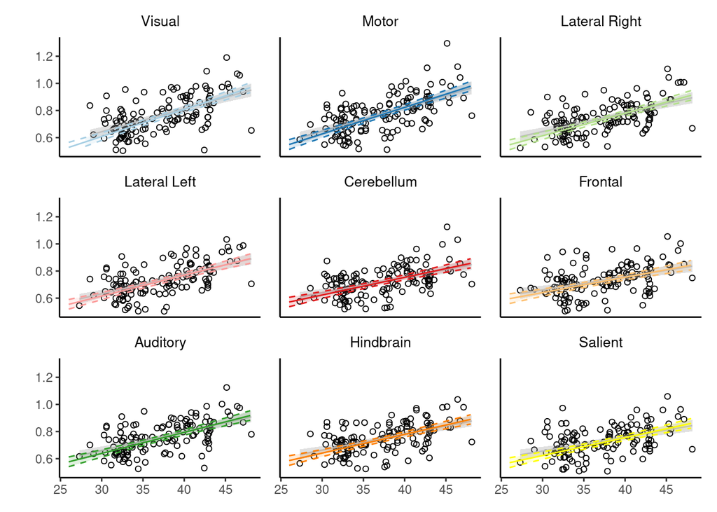

```r
patchworkrsn = visplot + motorplot + latrplot + latlplot + cerebellumplot + frontplot + auditoryplot + hindplot + salientplot
patchworkrsn[[1]] = patchworkrsn[[1]] + theme(axis.text.x = element_blank(),
                                        axis.ticks.x = element_blank(),
                                        axis.title.x = element_blank())
patchworkrsn[[2]] = patchworkrsn[[2]] + theme(axis.text.y = element_blank(),
                                        axis.ticks.y = element_blank(),
                                        axis.title.y = element_blank(),
                                        axis.text.x = element_blank(),
                                        axis.ticks.x = element_blank(),
                                        axis.title.x = element_blank())
patchworkrsn[[3]] = patchworkrsn[[3]] + theme(axis.text.y = element_blank(),
                                        axis.ticks.y = element_blank(),
                                        axis.title.y = element_blank(),
                                        axis.text.x = element_blank(),
                                        axis.ticks.x = element_blank(),
                                        axis.title.x = element_blank())
patchworkrsn[[3]] = patchworkrsn[[3]] + theme(axis.text.y = element_blank(),
                                        axis.ticks.y = element_blank(),
                                        axis.title.y = element_blank(),
                                        axis.text.x = element_blank(),
                                        axis.ticks.x = element_blank(),
                                        axis.title.x = element_blank())
patchworkrsn[[4]] = patchworkrsn[[4]] + theme(axis.text.x = element_blank(),
                                        axis.ticks.x = element_blank(),
                                        axis.title.x = element_blank())
patchworkrsn[[5]] = patchworkrsn[[5]] + theme(axis.text.y = element_blank(),
                                        axis.ticks.y = element_blank(),
                                        axis.title.y = element_blank(),
                                        axis.text.x = element_blank(),
                                        axis.ticks.x = element_blank(),
                                        axis.title.x = element_blank())
patchworkrsn[[6]] = patchworkrsn[[6]] + theme(axis.text.y = element_blank(),
                                        axis.ticks.y = element_blank(),
                                        axis.title.y = element_blank(),
                                        axis.text.x = element_blank(),
                                        axis.ticks.x = element_blank(),
                                        axis.title.x = element_blank())
patchworkrsn[[7]] = patchworkrsn[[7]] + theme(axis.title.x = element_blank())
patchworkrsn[[8]] = patchworkrsn[[8]] + theme(axis.text.y = element_blank(),
                                        axis.ticks.y = element_blank(),
                                        axis.title.y = element_blank(),
                                        axis.title.x = element_blank())
patchworkrsn[[9]] = patchworkrsn[[9]] + theme(axis.text.y = element_blank(),
                                        axis.ticks.y = element_blank(),
                                        axis.title.y = element_blank(),
                                        axis.title.x = element_blank())
patchworkrsn
```

```r
png(file="Figure6_roiplots.png", width=7, height=4, units="in", res=300)
patchworkrsn
dev.off()
```

Or another look:

```r
rsnslopes2 <- ggplot(Hpredictrsn, aes(x=x, y=predicted, color=group)) +
  geom_smooth(method="lm", se=F)+
  scale_color_manual(values=rsn.colors,limits = rsnnames3, labels = rsnnames2, name="RSN") +
  geom_dl(aes(label = group), method = "last.points", cex = 0.8) +
    labs(x='PMA at Scan (weeks)', y='Predicted H by ROI')  +
    theme(panel.grid.major = element_blank(), panel.grid.minor = element_blank(),
panel.background = element_blank(), axis.line = element_line(colour = "black"), legend.position = "none", plot.margin = unit(c(1,3,1,1), "lines")) +
  coord_cartesian(clip = 'off')
```

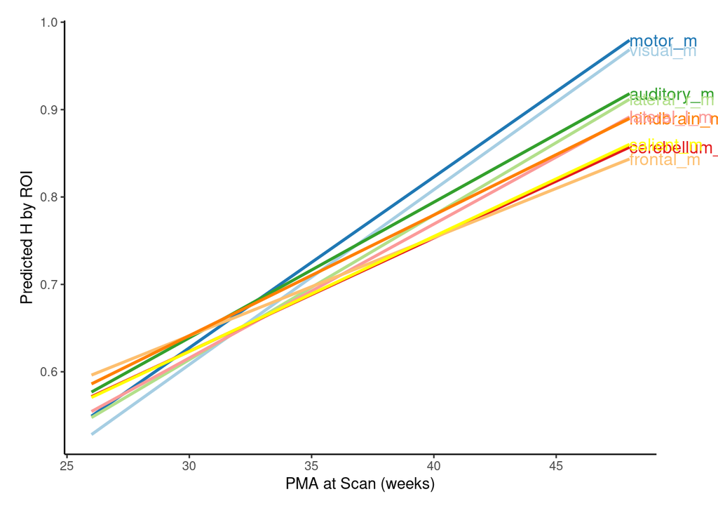

```r
rsnslopes2
```